# Risk Factor Analysis

## Outcome Variable

**Outcome Variable:** wasted

## Predictor Variables

**Intervention Variable:** hhwealth_quart

**Adjustment Set:**

unadjusted

## Stratifying Variables

The analysis was stratified on these variable(s):

- agecat
- studyid
- country

## Data Summary

| agecat | studyid | country | hhwealth_quart | wasted | n_cell | n |
| --- | --- | --- | --- | --- | --- | --- |
| Birth | COHORTS | GUATEMALA | Wealth Q4 | 0 | 190 | 729 |
| Birth | COHORTS | GUATEMALA | Wealth Q4 | 1 | 68 | 729 |
| Birth | COHORTS | GUATEMALA | Wealth Q1 | 0 | 98 | 729 |
| Birth | COHORTS | GUATEMALA | Wealth Q1 | 1 | 46 | 729 |
| Birth | COHORTS | GUATEMALA | Wealth Q2 | 0 | 108 | 729 |
| Birth | COHORTS | GUATEMALA | Wealth Q2 | 1 | 33 | 729 |
| Birth | COHORTS | GUATEMALA | Wealth Q3 | 0 | 148 | 729 |
| Birth | COHORTS | GUATEMALA | Wealth Q3 | 1 | 38 | 729 |
| Birth | COHORTS | PHILIPPINES | Wealth Q4 | 0 | 671 | 2898 |
| Birth | COHORTS | PHILIPPINES | Wealth Q4 | 1 | 144 | 2898 |
| Birth | COHORTS | PHILIPPINES | Wealth Q1 | 0 | 533 | 2898 |
| Birth | COHORTS | PHILIPPINES | Wealth Q1 | 1 | 114 | 2898 |
| Birth | COHORTS | PHILIPPINES | Wealth Q2 | 0 | 442 | 2898 |
| Birth | COHORTS | PHILIPPINES | Wealth Q2 | 1 | 64 | 2898 |
| Birth | COHORTS | PHILIPPINES | Wealth Q3 | 0 | 801 | 2898 |
| Birth | COHORTS | PHILIPPINES | Wealth Q3 | 1 | 129 | 2898 |
| 6 months | COHORTS | GUATEMALA | Wealth Q4 | 0 | 332 | 926 |
| 6 months | COHORTS | GUATEMALA | Wealth Q4 | 1 | 7 | 926 |
| 6 months | COHORTS | GUATEMALA | Wealth Q1 | 0 | 170 | 926 |
| 6 months | COHORTS | GUATEMALA | Wealth Q1 | 1 | 6 | 926 |
| 6 months | COHORTS | GUATEMALA | Wealth Q2 | 0 | 189 | 926 |
| 6 months | COHORTS | GUATEMALA | Wealth Q2 | 1 | 5 | 926 |
| 6 months | COHORTS | GUATEMALA | Wealth Q3 | 0 | 205 | 926 |
| 6 months | COHORTS | GUATEMALA | Wealth Q3 | 1 | 12 | 926 |
| 6 months | COHORTS | PHILIPPINES | Wealth Q4 | 0 | 715 | 2706 |
| 6 months | COHORTS | PHILIPPINES | Wealth Q4 | 1 | 29 | 2706 |
| 6 months | COHORTS | PHILIPPINES | Wealth Q1 | 0 | 520 | 2706 |
| 6 months | COHORTS | PHILIPPINES | Wealth Q1 | 1 | 49 | 2706 |
| 6 months | COHORTS | PHILIPPINES | Wealth Q2 | 0 | 453 | 2706 |
| 6 months | COHORTS | PHILIPPINES | Wealth Q2 | 1 | 32 | 2706 |
| 6 months | COHORTS | PHILIPPINES | Wealth Q3 | 0 | 857 | 2706 |
| 6 months | COHORTS | PHILIPPINES | Wealth Q3 | 1 | 51 | 2706 |
| 24 months | COHORTS | GUATEMALA | Wealth Q4 | 0 | 392 | 1046 |
| 24 months | COHORTS | GUATEMALA | Wealth Q4 | 1 | 13 | 1046 |
| 24 months | COHORTS | GUATEMALA | Wealth Q1 | 0 | 195 | 1046 |
| 24 months | COHORTS | GUATEMALA | Wealth Q1 | 1 | 8 | 1046 |
| 24 months | COHORTS | GUATEMALA | Wealth Q2 | 0 | 204 | 1046 |
| 24 months | COHORTS | GUATEMALA | Wealth Q2 | 1 | 11 | 1046 |
| 24 months | COHORTS | GUATEMALA | Wealth Q3 | 0 | 208 | 1046 |
| 24 months | COHORTS | GUATEMALA | Wealth Q3 | 1 | 15 | 1046 |
| 24 months | COHORTS | PHILIPPINES | Wealth Q4 | 0 | 654 | 2449 |
| 24 months | COHORTS | PHILIPPINES | Wealth Q4 | 1 | 31 | 2449 |
| 24 months | COHORTS | PHILIPPINES | Wealth Q1 | 0 | 447 | 2449 |
| 24 months | COHORTS | PHILIPPINES | Wealth Q1 | 1 | 45 | 2449 |
| 24 months | COHORTS | PHILIPPINES | Wealth Q2 | 0 | 396 | 2449 |
| 24 months | COHORTS | PHILIPPINES | Wealth Q2 | 1 | 28 | 2449 |
| 24 months | COHORTS | PHILIPPINES | Wealth Q3 | 0 | 785 | 2449 |
| 24 months | COHORTS | PHILIPPINES | Wealth Q3 | 1 | 63 | 2449 |

The following strata were considered:

- agecat: 24 months, studyid: COHORTS, country: GUATEMALA
- agecat: 24 months, studyid: COHORTS, country: PHILIPPINES
- agecat: 6 months, studyid: COHORTS, country: GUATEMALA
- agecat: 6 months, studyid: COHORTS, country: PHILIPPINES
- agecat: Birth, studyid: COHORTS, country: GUATEMALA
- agecat: Birth, studyid: COHORTS, country: PHILIPPINES

## Methods Detail

We’re interested in the causal parameters $E[Y_a]$ for all values of $a \in \mathcal{A}$. These parameters represent the mean outcome if, possibly contrary to fact, we intervened to set all units to have $A=a$. Under the randomization and positivity assumptions, these are identified by the statistical parameters $\psi_a=E_W[E_{Y|A,W}(Y|A=a,W)]$. In addition, we’re interested in the mean of $Y$, $E[Y]$ under no intervention (the observed mean). We will estimate these parameters by using SuperLearner to fit the relevant likelihood factors – $E_{Y|A,W}(Y|A=a,W)$ and $p(A=a|W)$, and then updating our likelihood fit using a joint TMLE.

For unadjusted analyses ($W=\{\}$), initial likelihoods were estimated using Lrnr_glm to estimate the simple $E(Y|A)$ and Lrnr_mean to estimate $p(A)$. For adjusted analyses, a small library containing Lrnr_glmnet, Lrnr_xgboost, and Lrnr_mean was used.

Having estimated these parameters, we will then use the delta method to estimate relative risks and attributable risks relative to a prespecified baseline level of $A$.

# Results Detail

## Results Plots

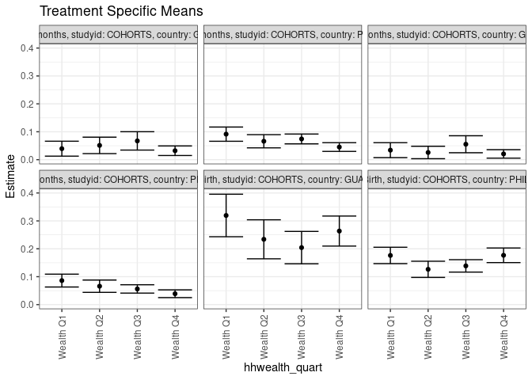

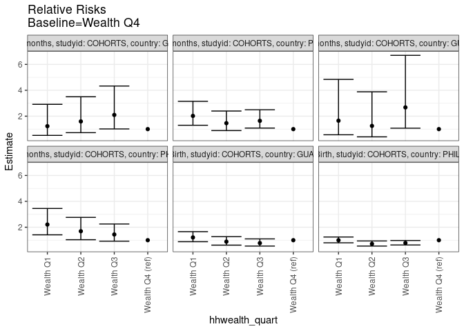

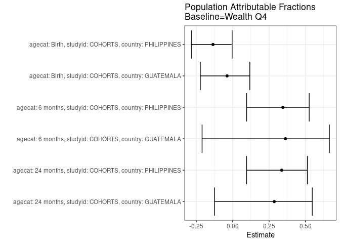

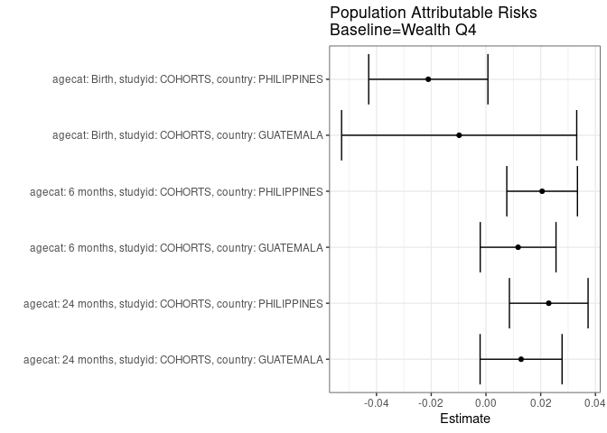

## Results Table

### Parameter: TSM

| agecat | studyid | country | intervention_level | baseline_level | estimate | ci_lower | ci_upper |
| --- | --- | --- | --- | --- | --- | --- | --- |
| Birth | COHORTS | GUATEMALA | Wealth Q4 | NA | 0.2635659 | 0.2097702 | 0.3173616 |
| Birth | COHORTS | GUATEMALA | Wealth Q1 | NA | 0.3194444 | 0.2432375 | 0.3956514 |
| Birth | COHORTS | GUATEMALA | Wealth Q2 | NA | 0.2340426 | 0.1641089 | 0.3039762 |
| Birth | COHORTS | GUATEMALA | Wealth Q3 | NA | 0.2043011 | 0.1463182 | 0.2622839 |
| Birth | COHORTS | PHILIPPINES | Wealth Q4 | NA | 0.1766871 | 0.1504975 | 0.2028767 |
| Birth | COHORTS | PHILIPPINES | Wealth Q1 | NA | 0.1761978 | 0.1468360 | 0.2055596 |
| Birth | COHORTS | PHILIPPINES | Wealth Q2 | NA | 0.1264822 | 0.0975156 | 0.1554489 |
| Birth | COHORTS | PHILIPPINES | Wealth Q3 | NA | 0.1387097 | 0.1164914 | 0.1609279 |
| 6 months | COHORTS | GUATEMALA | Wealth Q4 | NA | 0.0206490 | 0.0055029 | 0.0357951 |
| 6 months | COHORTS | GUATEMALA | Wealth Q1 | NA | 0.0340909 | 0.0072675 | 0.0609143 |
| 6 months | COHORTS | GUATEMALA | Wealth Q2 | NA | 0.0257732 | 0.0034634 | 0.0480830 |
| 6 months | COHORTS | GUATEMALA | Wealth Q3 | NA | 0.0552995 | 0.0248724 | 0.0857266 |
| 6 months | COHORTS | PHILIPPINES | Wealth Q4 | NA | 0.0389785 | 0.0250687 | 0.0528883 |
| 6 months | COHORTS | PHILIPPINES | Wealth Q1 | NA | 0.0861160 | 0.0630613 | 0.1091707 |
| 6 months | COHORTS | PHILIPPINES | Wealth Q2 | NA | 0.0659794 | 0.0438820 | 0.0880767 |
| 6 months | COHORTS | PHILIPPINES | Wealth Q3 | NA | 0.0561674 | 0.0411887 | 0.0711461 |
| 24 months | COHORTS | GUATEMALA | Wealth Q4 | NA | 0.0320988 | 0.0149241 | 0.0492734 |
| 24 months | COHORTS | GUATEMALA | Wealth Q1 | NA | 0.0394089 | 0.0126311 | 0.0661866 |
| 24 months | COHORTS | GUATEMALA | Wealth Q2 | NA | 0.0511628 | 0.0216976 | 0.0806280 |
| 24 months | COHORTS | GUATEMALA | Wealth Q3 | NA | 0.0672646 | 0.0343737 | 0.1001555 |
| 24 months | COHORTS | PHILIPPINES | Wealth Q4 | NA | 0.0452555 | 0.0296861 | 0.0608248 |
| 24 months | COHORTS | PHILIPPINES | Wealth Q1 | NA | 0.0914634 | 0.0659864 | 0.1169405 |
| 24 months | COHORTS | PHILIPPINES | Wealth Q2 | NA | 0.0660377 | 0.0423941 | 0.0896814 |
| 24 months | COHORTS | PHILIPPINES | Wealth Q3 | NA | 0.0742925 | 0.0566383 | 0.0919467 |

### Parameter: E(Y)

| agecat | studyid | country | intervention_level | baseline_level | estimate | ci_lower | ci_upper |
| --- | --- | --- | --- | --- | --- | --- | --- |
| Birth | COHORTS | GUATEMALA | NA | NA | 0.2537723 | 0.2221611 | 0.2853834 |
| Birth | COHORTS | PHILIPPINES | NA | NA | 0.1556246 | 0.1424244 | 0.1688248 |
| 6 months | COHORTS | GUATEMALA | NA | NA | 0.0323974 | 0.0209875 | 0.0438073 |
| 6 months | COHORTS | PHILIPPINES | NA | NA | 0.0594974 | 0.0505830 | 0.0684118 |
| 24 months | COHORTS | GUATEMALA | NA | NA | 0.0449331 | 0.0323731 | 0.0574931 |
| 24 months | COHORTS | PHILIPPINES | NA | NA | 0.0681911 | 0.0582056 | 0.0781766 |

### Parameter: RR

| agecat | studyid | country | intervention_level | baseline_level | estimate | ci_lower | ci_upper |
| --- | --- | --- | --- | --- | --- | --- | --- |
| Birth | COHORTS | GUATEMALA | Wealth Q4 | Wealth Q4 | 1.0000000 | 1.0000000 | 1.0000000 |
| Birth | COHORTS | GUATEMALA | Wealth Q1 | Wealth Q4 | 1.2120098 | 0.8854314 | 1.6590419 |
| Birth | COHORTS | GUATEMALA | Wealth Q2 | Wealth Q4 | 0.8879850 | 0.6183722 | 1.2751500 |
| Birth | COHORTS | GUATEMALA | Wealth Q3 | Wealth Q4 | 0.7751423 | 0.5464613 | 1.0995208 |
| Birth | COHORTS | PHILIPPINES | Wealth Q4 | Wealth Q4 | 1.0000000 | 1.0000000 | 1.0000000 |
| Birth | COHORTS | PHILIPPINES | Wealth Q1 | Wealth Q4 | 0.9972308 | 0.7978792 | 1.2463908 |
| Birth | COHORTS | PHILIPPINES | Wealth Q2 | Wealth Q4 | 0.7158542 | 0.5449403 | 0.9403732 |
| Birth | COHORTS | PHILIPPINES | Wealth Q3 | Wealth Q4 | 0.7850582 | 0.6311349 | 0.9765209 |
| 6 months | COHORTS | GUATEMALA | Wealth Q4 | Wealth Q4 | 1.0000000 | 1.0000000 | 1.0000000 |
| 6 months | COHORTS | GUATEMALA | Wealth Q1 | Wealth Q4 | 1.6509740 | 0.5630837 | 4.8406932 |
| 6 months | COHORTS | GUATEMALA | Wealth Q2 | Wealth Q4 | 1.2481591 | 0.4013444 | 3.8817062 |
| 6 months | COHORTS | GUATEMALA | Wealth Q3 | Wealth Q4 | 2.6780777 | 1.0705381 | 6.6995283 |
| 6 months | COHORTS | PHILIPPINES | Wealth Q4 | Wealth Q4 | 1.0000000 | 1.0000000 | 1.0000000 |
| 6 months | COHORTS | PHILIPPINES | Wealth Q1 | Wealth Q4 | 2.2093206 | 1.4142059 | 3.4514759 |
| 6 months | COHORTS | PHILIPPINES | Wealth Q2 | Wealth Q4 | 1.6927124 | 1.0376205 | 2.7613904 |
| 6 months | COHORTS | PHILIPPINES | Wealth Q3 | Wealth Q4 | 1.4409844 | 0.9229603 | 2.2497564 |
| 24 months | COHORTS | GUATEMALA | Wealth Q4 | Wealth Q4 | 1.0000000 | 1.0000000 | 1.0000000 |
| 24 months | COHORTS | GUATEMALA | Wealth Q1 | Wealth Q4 | 1.2277378 | 0.5170124 | 2.9154814 |
| 24 months | COHORTS | GUATEMALA | Wealth Q2 | Wealth Q4 | 1.5939177 | 0.7262154 | 3.4983748 |
| 24 months | COHORTS | GUATEMALA | Wealth Q3 | Wealth Q4 | 2.0955502 | 1.0150945 | 4.3260315 |
| 24 months | COHORTS | PHILIPPINES | Wealth Q4 | Wealth Q4 | 1.0000000 | 1.0000000 | 1.0000000 |
| 24 months | COHORTS | PHILIPPINES | Wealth Q1 | Wealth Q4 | 2.0210464 | 1.2981696 | 3.1464522 |
| 24 months | COHORTS | PHILIPPINES | Wealth Q2 | Wealth Q4 | 1.4592209 | 0.8881355 | 2.3975235 |
| 24 months | COHORTS | PHILIPPINES | Wealth Q3 | Wealth Q4 | 1.6416236 | 1.0806499 | 2.4938030 |

### Parameter: PAR

| agecat | studyid | country | intervention_level | baseline_level | estimate | ci_lower | ci_upper |
| --- | --- | --- | --- | --- | --- | --- | --- |
| Birth | COHORTS | GUATEMALA | Wealth Q4 | NA | -0.0097936 | -0.0527451 | 0.0331579 |
| Birth | COHORTS | PHILIPPINES | Wealth Q4 | NA | -0.0210625 | -0.0428422 | 0.0007171 |
| 6 months | COHORTS | GUATEMALA | Wealth Q4 | NA | 0.0117484 | -0.0020944 | 0.0255913 |
| 6 months | COHORTS | PHILIPPINES | Wealth Q4 | NA | 0.0205189 | 0.0076133 | 0.0334246 |
| 24 months | COHORTS | GUATEMALA | Wealth Q4 | NA | 0.0128343 | -0.0021425 | 0.0278111 |
| 24 months | COHORTS | PHILIPPINES | Wealth Q4 | NA | 0.0229356 | 0.0085651 | 0.0373061 |

### Parameter: PAF

| agecat | studyid | country | intervention_level | baseline_level | estimate | ci_lower | ci_upper |
| --- | --- | --- | --- | --- | --- | --- | --- |
| Birth | COHORTS | GUATEMALA | Wealth Q4 | NA | -0.0385921 | -0.2223922 | 0.1175717 |
| Birth | COHORTS | PHILIPPINES | Wealth Q4 | NA | -0.1353420 | -0.2839735 | -0.0039161 |
| 6 months | COHORTS | GUATEMALA | Wealth Q4 | NA | 0.3626352 | -0.2100558 | 0.6642850 |
| 6 months | COHORTS | PHILIPPINES | Wealth Q4 | NA | 0.3448708 | 0.0956664 | 0.5254027 |
| 24 months | COHORTS | GUATEMALA | Wealth Q4 | NA | 0.2856317 | -0.1247612 | 0.5462841 |
| 24 months | COHORTS | PHILIPPINES | Wealth Q4 | NA | 0.3363434 | 0.0955045 | 0.5130544 |